# DESeq2 Analysis

Trushar Shah and Manpreet Katari

6/20/2018

This excercise will take you through an example of DE analysis using the DESeq2 package

DESeq2 requires a matrix of raw count data as the input file (no normalised data or any other values)

The first step is to load the counts data from the individual files. Please ensure that you have all the datafiles in a single directory and set the working directory

# Load data files

```r
setwd("~/Documents/Bioinformatics Workshops/BioinfoCoP")
allfiles= dir(pattern="v1.tophat.dedup_sorted.bam.count")
```

load all the count file

```r
for(filename in allfiles) {
  tmpfilename = strsplit(x = filename,
                         split=".",
                         fixed = T)
  objname = strsplit(tmpfilename[[1]][1],
                     split="-",
                     fixed=T)
  newobjname=paste(objname[[1]], collapse="_")
  assign(newobjname,
         read.table(filename, row.names = 1)
  )
}
```

combine all the variables into one dataframe.

```r
allcounts = cbind(k12_1,k12_2,k12_3,k48_1,k48_2,k48_3,
                  kx0_1,kx0_2,kx0_3,kx12_1,kx12_2,kx12_3,
                  kx48_1,kx48_2,kx48_3,
                  m12_1,m12_2,m12_3,m48_1,m48_2,m48_3,
                  mx0_1,mx0_2,mx0_3,mx12_1,mx12_2,mx12_3,
                  mx48_1,mx48_2,mx48_3)
```

assign the column names

```r
colnames(allcounts)=c("k12_1","k12_2","k12_3","k48_1","k48_2","k48_3",
                      "kx0_1","kx0_2","kx0_3","kx12_1","kx12_2","kx12_3",
                      "kx48_1","kx48_2","kx48_3",
                      "m12_1","m12_2","m12_3","m48_1","m48_2","m48_3",
                      "mx0_1","mx0_2","mx0_3","mx12_1","mx12_2","mx12_3",
                      "mx48_1","mx48_2","mx48_3")
```

remove all lines that start with “__"

```r
allcounts_stats = allcounts[-grep("__", row.names(allcounts)),]
allcounts = allcounts[grep("__", row.names(allcounts),invert=TRUE),]
```

Perform some quality control on the readcounts, this is optional as DESeq also has some filtering criteria

```r
expgroup = c("k12","k12","k12","k48","k48","k48",
             "kx0","kx0","kx0","kx12","kx12","kx12",
             "kx48","kx48","kx48",
             "m12","m12","m12","m48","m48","m48",
             "mx0","mx0","mx0","mx12","mx12","mx12",
             "mx48","mx48","mx48")


medianCountByGroup = t(apply(allcounts, 1, tapply,
                             expgroup, median))

maxMedian=apply(medianCountByGroup, 1, max)
```

remove all genes where the median of the max samples is <10

```r
allcounts[maxMedian>=10,]->allcounts_filtered
```

Plot the histogram before and after filtering

```r
pdf("SampleMedianByGroup.pdf")
par(mfrow=c(2,1))
hist(log2(maxMedian), xlim=c(0,20), col = "gray")
hist(log2(maxMedian[maxMedian>=10]), xlim=c(0,20),
     col="gray")
dev.off()
```

# Experimental Design

Define the experimental design of the study described

```r
gen_group = factor(c("k","k","k","k","k","k",
                     "k","k","k","k","k","k",
                     "k","k","k",
                     "m","m","m","m","m","m",
                     "m","m","m",
                     "m","m","m","m","m","m"))


time_group = c("12","12","12","48","48","48",
               "0","0","0","12","12","12",
               "48","48","48",
               "12","12","12","48","48","48",
               "0","0","0","12","12","12",
               "48","48","48")


treatment_group = c("ctl","ctl","ctl","ctl","ctl","ctl",
                    "ctl","ctl","ctl","trt","trt","trt",
                    "trt","trt","trt",
                    "ctl","ctl","ctl","ctl","ctl","ctl",
                    "ctl","ctl","ctl","trt","trt","trt",
                    "trt","trt","trt")



expdesign = data.frame(genotype=gen_group,
                       time=time_group,
                       treatment=treatment_group)

rownames(expdesign)=colnames(allcounts_filtered)


library(DESeq2)
```

# DESeq2 analysis

The model definition is important Below we anlayse time 12 for both genotypes

```r
time12counts = allcounts_filtered[,time_group=="12"]
time12expdesign = expdesign[time_group=="12",]


time12ddsMat <- DESeqDataSetFromMatrix(countData = time12counts,
                                        colData = time12expdesign,
                                        design = ~ genotype + treatment + genotype:treatment)


time12ddsMat <- DESeq(time12ddsMat)
```

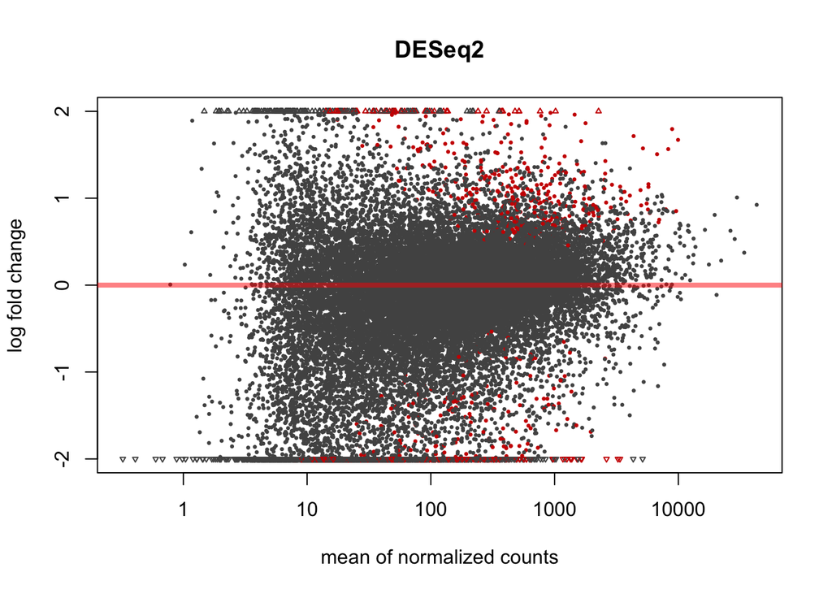

```r
res12Wald<-results(time12ddsMat)

plotMA(time12ddsMat,ylim=c(-2,2),main="DESeq2")
```

```r
resultsNames(time12ddsMat)
```

```
## [1] "Intercept"              "genotype_m_vs_k"
## [3] "treatment_trt_vs_ctl"   "genotypem.treatmenttrt"
```

To look up a specific gene

```r
res12Wald["GSMUA_Achr7G18930_001",]
```

```
## log2 fold change (MLE): genotypem.treatmenttrt
## Wald test p-value: genotypem.treatmenttrt
## DataFrame with 1 row and 6 columns
##                               baseMean    log2FoldChange             lfcSE
##                              <numeric>         <numeric>         <numeric>
## GSMUA_Achr7G18930_001 131.973598349709 -4.17258982116564 0.915440996848103
##                                    stat               pvalue
##                               <numeric>            <numeric>
## GSMUA_Achr7G18930_001 -4.55801065883221 5.16404173401625e-06
##                                      padj
##                                 <numeric>
## GSMUA_Achr7G18930_001 0.00356352231547049
```

Look at the Top 20 significant genes

```r
time12_top20_gentrt<-head(res12Wald[order(res12Wald$padj),], 20)
```

# Annotation of the data

This is the get annotation function

```r
library(GO.db)
getannotation<-function(annofile, genelist) {

  anno<-read.table(annofile,
                   header=FALSE,
                   sep="\t",
                   quote="",
                   comment.char="")

  justAnno<-anno[as.character(anno[,2]) %in% row.names(genelist), c(2,10:16)]

  gene_name=character()
  go_annot=character()
  arth_gene=character()
  arth_alias=character()
  arth_description=character()
  rice_gene=character()
  rice_alias=character()
  rice_description=character()

  for (i in 1:nrow(justAnno)) {
    gene_name[i]=as.character(justAnno[i,1])
    go=unlist(strsplit(as.character(justAnno[i,2]),","))

    go_annot[i] = paste(names(Term(go)),Term(go), collapse=" ; ")

    arth_gene[i]=as.character(justAnno[,3])[i]
    arth_alias[i]=as.character(justAnno[,4])[i]
    arth_description[i]=as.character(justAnno[,5])[i]
    rice_gene[i]=as.character(justAnno[,6])[i]
    rice_alias[i]=as.character(justAnno[,7])[i]
    rice_description[i]=as.character(justAnno[,8])[i]


  }

  return(data.frame(gene_name,
                    log2fc=genelist$log2FoldChange,
                    padj=genelist$padj,
                    go_annot,
                    arth_gene,
                    arth_alias,arth_description,
                    rice_gene,rice_alias,
                    rice_description))

}
```

This step utilises the file downloaded from Phytozome and annotates it

```r
time12_top20_gentrt_annotation<-getannotation("./Macuminata_304_v1.annotation_info.txt", time12_top20_gentrt)
write.csv(time12_top20_gentrt_annotation,file="./time12_all_top20_gentrt_annotation.csv")
```

Here’s a function to filter DESeq2 results based on a adjusted p-value of 0.05 and a 2 fold change

```r
filterDeseq2<-function(res) {

  filtpadj = (!is.na(res[,"padj"]) & res[,"padj"] < 0.05)
  filtfoldchange = (res[,"log2FoldChange"] <= -1 | res[,"log2FoldChange"] >= 1)
  filtlogic = filtpadj & filtfoldchange
  newres = res[filtlogic,]
  return(newres)

}



res12Wald_filtered<-filterDeseq2(res12Wald)
res12Wald_filtered_annotation<-getannotation("./Macuminata_304_v1.annotation_info.txt", res12Wald_filtered)
write.csv(res12Wald_filtered_annotation,file="./time12_final_filtered_gentrt_annotation.csv")
```

Load tidyr and dplyr

```r
library(tidyr)
library(dplyr)
```

filters out those without Arabidopsis gene for Mapman analysis

```r
res12Wald_filtered_annotation_ath<-res12Wald_filtered_annotation[!res12Wald_filtered_annotation$arth_gene=="",]
res12Wald_filtered_annotation_ath$arth_gene<-gsub("\\.*","",res12Wald_filtered_annotation_ath$arth_gene)
res12Wald_filtered_annotation_ath_final<-res12Wald_filtered_annotation_ath %>% group_by(res12Wald_filtered_annotation_ath$arth_gene) %>% mutate(Sum = cumsum(log2fc))
write.table(summarise(res12Wald_filtered_annotation_ath_final,log2fc=mean(log2fc),count=n()),"./res12Wald_filtered_annotation_ath_final.txt", sep = "\t", row.names = F)
```